# Assignment 1

June 12, 2016

## Setting up global options

```r
        setwd("C:/Users/Konstantinos/Dropbox/R/Reproducible Research/Assignment 1/RepData_PeerAssessment1")
        knitr::opts_chunk$set(echo = TRUE)

        library(ggplot2)

        options(digits = 2)
```

## Loading and pre-processing the dataset

Loading the dataset:

```r
        myDF <- read.csv("activity.csv",
                        sep = ",",
                        header = TRUE,
                        na.strings = "NA",
                        colClasses = c("integer", "Date", "integer"))

        myDF_rows <- nrow(myDF)
```

Renaming the data columns into something more “human”, and identifying missing values:

```r
        colnames(myDF)[colnames(myDF)=="steps"] <- "Steps_Taken"
        colnames(myDF)[colnames(myDF)=="date"] <- "Date_Reference"
        colnames(myDF)[colnames(myDF)=="interval"] <-"Time_Interval"

        myDF$DaysSinceStart <- difftime(myDF$Date_Reference, min(myDF$Date_Reference), units = "days")

        mValues <- sum(is.na(myDF$Steps_Taken))
```

The main dataset has 17568 rows, which should be the number expected.

## Total number of steps per day

```r
        temp <- aggregate(myDF$Steps_Taken, by = list(myDF$DaysSinceStart), sum)
        colnames(temp)[colnames(temp)=="Group.1"] <- "DaysSinceStart"
        colnames(temp)[colnames(temp)=="x"] <- "Steps_Taken"

        temp$Date_Reference <- min(myDF$Date_Reference) + temp$DaysSinceStart
```

The following histogram presents the distribution of steps taken at any given day:

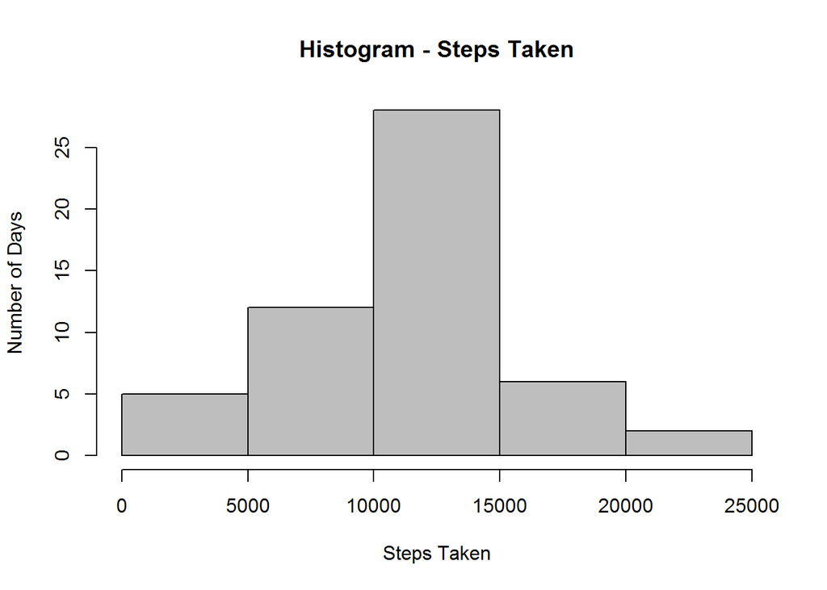

```r
        hist(temp$Steps_Taken,
                main = "Histogram - Steps Taken", xlab = "Steps Taken", ylab = "Number of Days", col = "grey")
```

```r
        AverageStepsTaken <- mean(temp$Steps_Taken, na.rm = TRUE)
        MedianStepsTaken <- median(temp$Steps_Taken, na.rm = TRUE)
```

## Average daily activity pattern

We then show the activity pattern on any given day:

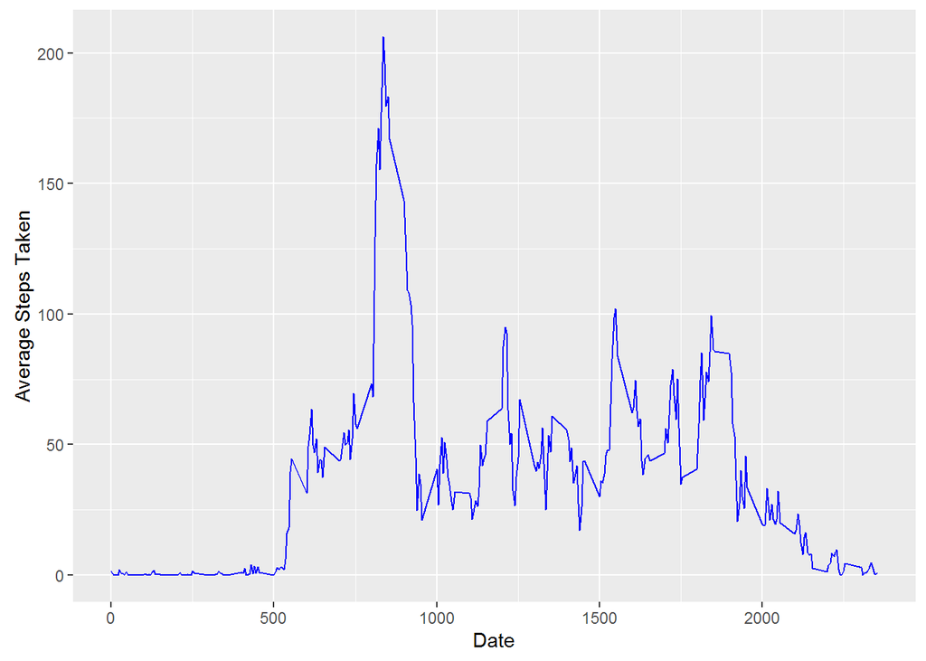

```r
        temp_Avg5 <- aggregate(myDF$Steps_Taken, by = list(myDF$Time_Interval), FUN = mean, na.rm = TRUE)
        colnames(temp_Avg5)[colnames(temp_Avg5)=="Group.1"] <- "Interval"
        colnames(temp_Avg5)[colnames(temp_Avg5)=="x"] <- "AverageStepsTaken"

        ggplot(temp_Avg5, aes(x = temp_Avg5$Interval, y = temp_Avg5$AverageStepsTaken)) +
                geom_line(colour = "blue", size = 0.5) +
                xlab("Date") +
                ylab("Average Steps Taken")
```

```r
        max5m <- temp_Avg5[which.max(temp_Avg5$AverageStepsTaken),]
```

It is evident that there are “zones” of activity during the day, but this is beyond the scope of this report.

## Correcting missing values

Out of a total of 17568 observations, 2304 are missing.

We have chosen to replace those missing values with the Median daily steps allocated to the 5-minute interval (i.e., divided by 288 5-minute intervals in the day).

```r
        myDF_Prime <- myDF
        myDF_Prime$Steps_Taken[is.na(myDF_Prime$Steps_Taken)] <- (MedianStepsTaken / 288)

        mValues_Prime <- sum(is.na(myDF_Prime$Steps_Taken))

        temp_Prime <- aggregate(myDF_Prime$Steps_Taken, by = list(myDF_Prime$DaysSinceStart), sum)
        colnames(temp_Prime)[colnames(temp_Prime)=="Group.1"] <- "DaysSinceStart"
        colnames(temp_Prime)[colnames(temp_Prime)=="x"] <- "Steps_Taken"

        temp_Prime$Date_Reference <- min(myDF_Prime$Date_Reference) + temp_Prime$DaysSinceStart
```

We plot once again the distribution of steps per day, after correcting for missing values:

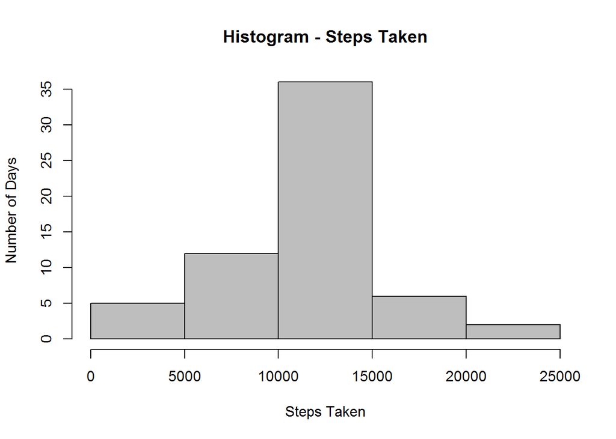

```r
        hist(temp_Prime$Steps_Taken,
                main = "Histogram - Steps Taken", xlab = "Steps Taken", ylab = "Number of Days", col = "grey")
```

```r
        AverageStepsTaken_Prime <- mean(temp_Prime$Steps_Taken, na.rm = TRUE)
        MedianStepsTaken_Prime <- median(temp_Prime$Steps_Taken, na.rm = TRUE)
```

## Differences in activity patterns between weekdays and weekends

To understand differences in activity patterns, we plot the average steps taken (per 5-minute time interval) during weekends and weekdays.

To do so, we first identify weekends and weekdays in the dataset:

```r
        myDF_Prime$Date_Reference <- as.Date(myDF_Prime$Date_Reference)

        weekdays1 <- c('Monday', 'Tuesday', 'Wednesday', 'Thursday', 'Friday')

        myDF_Prime$wDay <- factor(weekdays(myDF_Prime$Date_Reference) %in% weekdays1,
                                  levels = c(FALSE, TRUE),
                                  labels = c("weekend", "weekday"))
```

… and then proceed with the relevant plots:

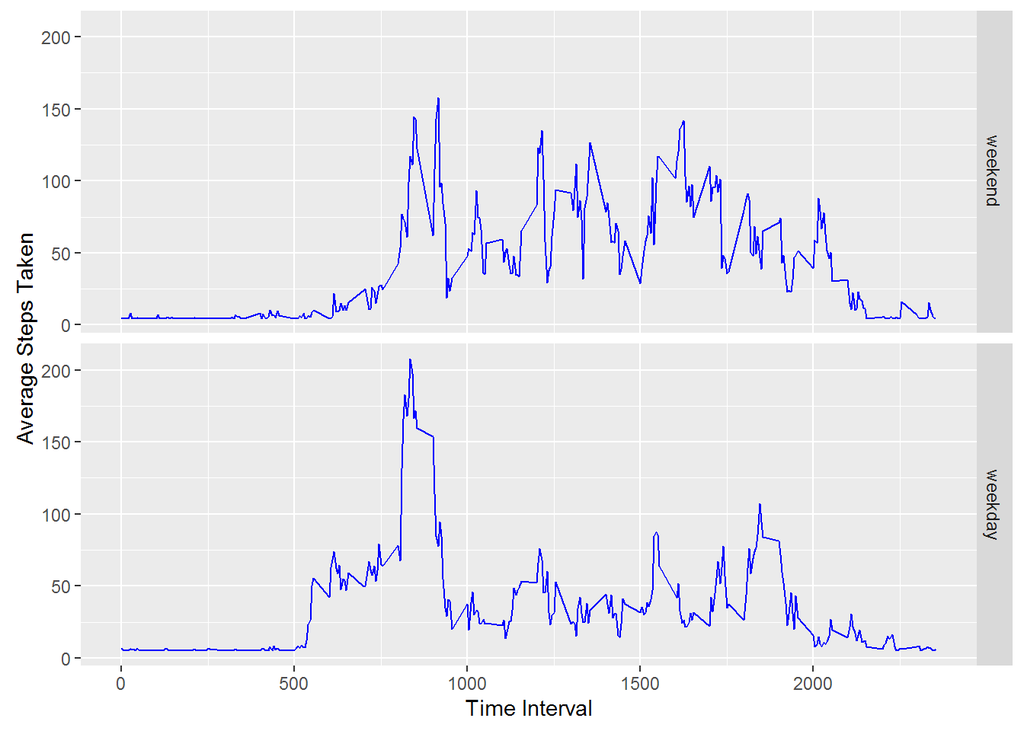

```r
        temp_Prime_Avg5 <- aggregate(myDF_Prime$Steps_Taken,
                                     by = list(myDF_Prime$wDay, myDF_Prime$Time_Interval),
                                     FUN = mean, na.rm = TRUE)

        colnames(temp_Prime_Avg5)[colnames(temp_Prime_Avg5)=="Group.1"] <- "DayType"
        colnames(temp_Prime_Avg5)[colnames(temp_Prime_Avg5)=="Group.2"] <- "Time_Interval"
        colnames(temp_Prime_Avg5)[colnames(temp_Prime_Avg5)=="x"] <- "Steps_Taken"

        ggplot(temp_Prime_Avg5, aes(x = Time_Interval, y = Steps_Taken, group = DayType)) +
                geom_line(colour = "blue", size = 0.5) +
                facet_grid(DayType ~ .) +
                xlab("Time Interval") +
                ylab("Average Steps Taken")
```